# Preprocessing/Cleaning

Ruitian Liu, Zhiye Jiang, Yuyu Zhang, Tommy Yu

2026-02-27

```r
# Data Preparation and Cleaning
### Load necessary libraries, covering data processing, string manipulation, visualization, and diagnostic analysis
library(stringr)
library(dplyr)
library(tableone)
library(tidyr)
library(patchwork)
library(purrr)
library(rcompanion)
library(psych)
library(ggplot2)
library(dlookr)
library(modelsummary)
library(broom)
library(forcats)
library(ggplot2)
```

```r
# Please ensure the file exists at this path
df <- read.table("STAR.tab", header = TRUE, sep = "\t")
```

```r
## Phase 1: Column Name Filtering and Cleanin
# Truncate column names to the first 8 characters; STAR dataset column names usually contain grade prefixes (e.g., gk, g1, etc.)
names(df) <- substr(names(df), 1, 8)
cols <- names(df)

# Use regular expressions to extract column names starting with gk, g1, g2, g3
m <- regexpr("^(gk|g1|g2|g3)(.*)$", cols, perl = TRUE)
prefix <- regmatches(cols, m)
suffix <- sub("^(gk|g1|g2|g3)", "", prefix)

# Count the frequency of each variable and filter variables that exist across all grades (appearing at least 4 times)
tab <- table(suffix)
valid_suffix <- names(tab[tab >= 4])

# Construct the list of column names to keep
keep_cols <- unlist(lapply(valid_suffix, function(s) paste0(c("gk","g1","g2","g3"), s)))

# Separate basic student information (assuming the first 6 columns are basic info) and teaching data corresponding to grades
student_info <- df[, 1:6, drop = FALSE]
df_keep <- df[, intersect(names(df), keep_cols), drop = FALSE]
star <- cbind(student_info, df_keep)
```

```r
## Phase 2: Data Reshaping (Wide to Long -> Long to Wide)
# Convert the dataset from wide format to long format, then back to wide format, to standardize the grade structure
stars <- star %>%
  pivot_longer(cols = matches("^(gk|g1|g2|g3)"),
               names_to = c("grade", "variable"),
               names_pattern = "^g([k123])(.*)$", # Capture grade (k, 1, 2, 3) and variable names
               values_to = "value") %>%
  pivot_wider(names_from = variable,
              values_from = value) %>%
  # Convert the grade column into an ordered factor
  mutate(grade = dplyr::recode(grade, k = "K"),
         grade = factor(grade, levels = c("K", "1", "2", "3"), ordered = FALSE))
```

```r
## Phase 3: Renaming and Variable Type Conversion
# Standardize variable names to make them more readable
stars <- stars %>% rename(
  student_id = stdntid, birth_month = birthmon, birth_day = birthday,
  birth_year = birthyea, teaching_years = tyears, class_size = classs,
  math_score = tmaths, school_id = schid, teacher_id = tchid)
stars_diag <- stars %>% rename(area_type = surban, class_type = classt, teacher_degree = thighd,
    teacher_career = tcaree, student_gender = gender, teacher_gender = tgen,
    free_lunch = freelu, teacher_race = trace, student_race = race)

stars_diag[c("area_type","class_type","teacher_degree","teacher_career",
             "student_gender","teacher_gender","free_lunch",
             "teacher_race","student_race")] <-
  lapply(stars_diag[c("area_type","class_type","teacher_degree","teacher_career",
                      "student_gender","teacher_gender","free_lunch",
                      "teacher_race","student_race")], factor)

stars_diag %>% dplyr::filter(if_all(where(is.factor), ~ !is.na(.))) %>% diagnose_category()
```

```
## # A tibble: 38 × 6
##    variables      levels     N  freq   ratio  rank
##    <chr>          <chr>  <int> <int>   <dbl> <int>
##  1 student_gender 1      25013 12957 51.8        1
##  2 student_gender 2      25013 12056 48.2        2
##  3 student_race   1      25013 16648 66.6        1
##  4 student_race   2      25013  8221 32.9        2
##  5 student_race   3      25013    63  0.252      3
##  6 student_race   6      25013    35  0.140      4
##  7 student_race   4      25013    33  0.132      5
##  8 student_race   5      25013    13  0.0520     6
##  9 grade          1      25013  6583 26.3        1
## 10 grade          3      25013  6442 25.8        2
## # ℹ 28 more rows
```

Following the Project STAR codebook, we recoded several categorical variables and collapsed categories when the original coding was too sparse for stable analysis. In particular, student race and teacher race were simplified to Black vs. Non-Black, since the STAR documentation shows that racial categories other than White and Black were extremely rare in the data. Teacher degree was reduced to Below Master versus Master or above, because specialist and doctoral categories were infrequent relative to the dominant bachelor’s/master’s groups. Teacher career stage was also collapsed into Lower level and Upper level, since the original multi-level ladder structure was highly imbalanced in practice.

```r
## Phase 4: Feature Engineering and Variable Cleaning
# Use case_when to create more descriptive categorical variables and delete unnecessary raw variables
stars1 <- stars %>% mutate(
  # Area type encoding conversion
  area_type = factor(case_when(
    surban == 1 ~ "Inner City",
    surban == 2 ~ "Suburban",
    surban == 3 ~ "Rural",
    surban == 4 ~ "Urban",
    TRUE ~ NA_character_)),
  # Class type encoding conversion
  class_type = factor(classt, levels = c(1, 2, 3),
                      labels = c("Small class", "Regular class", "Regular + aide")),
  # Teacher degree level binning
  teacher_degree = factor(case_when(
    thighd %in% c(1, 2) ~ "Below Master",
    thighd %in% c(3, 4, 5, 6) ~ "Master or above",
    TRUE ~ NA_character_),
    levels = c("Below Master", "Master or above"), ordered = TRUE),
  # Teacher career stage binning
  teacher_career = factor(case_when(
    tcaree %in% c(1, 2, 3) ~ "Lower level",
    tcaree %in% c(4, 5, 6, 7) ~ "Upper level",
    TRUE ~ NA_character_),
    levels = c("Lower level", "Upper level"), ordered = TRUE),
  # Gender and free lunch encoding conversion
  student_gender = factor(gender, levels = c(1, 2),
                          labels = c("Male", "Female")),
  teacher_gender = factor(tgen, levels = c(1, 2),
                          labels = c("Male", "Female")),
  free_lunch = factor(freelu, levels = c(1, 2),
                      labels = c("Free lunch", "Non-free lunch")),
  # Racial binarization
  teacher_race = factor(case_when(
    trace == 2 ~ "Black",
    trace %in% c(1, 3, 4, 5, 6) ~ "Non-Black",
    TRUE ~ NA_character_),
    levels = c("Black", "Non-Black")),
  student_race = factor(case_when(
    race == 2 ~ "Black",
    race %in% c(1, 3, 4, 5, 6) ~ "Non-Black",
    TRUE ~ NA_character_),
    levels = c("Black", "Non-Black"))
) %>%
  # Delete the converted raw variables and analysis indicators that are no longer needed; here, we only keep the math scores for performance variables
  select(-surban, -classt, -thighd, -gender, -race, -tcaree, -tgen, -freelu, -trace, -starts_with("gk"))
```

## Identification of potential confounder

Let the variables be defined as follows:

- $Y$: Outcome variable — students’ **math scores**.
- $X$: Treatment variables — **class type, grade level, and their interaction (class type × grade)**.
- $Z$: Potential confounders — **school area type, free lunch status, student race, teacher race, and teacher degree, etc**.
- $A$: Ancillary variables — **treads (reading), tlists (listening), wordsk (word skills), motivr (motivation), selfco (self-concept), and lagged math scores from previous grades**.

Our objective is to estimate the effect of class size on students’ mathematics achievement in the STAR experiment. Although the initial assignment was randomized, factors such as classroom reassignment and student mobility may weaken the ideal experimental conditions. As a result, background characteristics may influence both classroom assignment and student outcomes.

A variable $Z$ acts as a confounder if it is associated with both the treatment $X$ (class type) and the outcome $Y$ (math score). Thus we examine three relationships:

- **$X \rightarrow Y$:** whether class type is associated with math achievement.
- **$Z \rightarrow Y$:** whether background characteristics are associated with math achievement.
- **$Z \rightarrow X$ or $X \leftarrow Z \rightarrow Y$:** whether background characteristics are related to classroom assignment.

If these relationships hold, failing to control for $Z$ may bias estimates of the effect of class size on student outcomes. Therefore, these variables are included as controls in the subsequent analysis.

### Verify **$X \rightarrow Y$:**

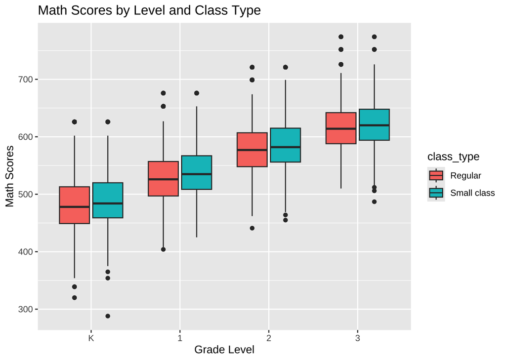

```r
# Plots and Graphs
library(ggplot2)
stars1 <- stars1 %>%
  mutate(class_type = case_when(
    class_type %in% c("Regular class", "Regular + aide") ~ "Regular",
    TRUE ~ class_type
  )) %>%
  mutate(class_type = as.factor(class_type))
ggplot(data=stars1, mapping=aes(y=math_score,x=grade,fill=class_type)) +
   geom_boxplot(na.rm=TRUE) +
   xlab('Grade Level')+ ylab('Math Scores') +
   ggtitle('Math Scores by Level and Class Type')
```

The boxplots show the distribution of students’ mathematics scores by grade level (K–3) and class type (small class/regular class). We can see that math scores increase steadily across grades. Also, students in small classes consistently exhibit slightly higher math scores than those in regular classes within the same grade. Thirdly, the difference between small classes and regular classes appears to persist across all grade levels, suggesting a potential interaction between grade and class type. In particular, the gap between the two class types appears to be slightly larger in lower grades. Thus, we can say that $X \rightarrow Y$ exists.

### Examine potential variables that **$Z \rightarrow Y$:**

[figure not shown]

```r
library(patchwork)
options(warn = -1)
cat_vars <- c("area_type", "class_type", "teacher_degree", "teacher_career",
              "student_gender", "teacher_gender", "free_lunch", "teacher_race", "student_race")
make_all_plots <- function(df, cont, cats, ncol = 3) {
  cont_lab <- pretty_label(cont)
  one_cat <- function(cat_var) {
    d <- dplyr::filter(df, !is.na(.data[[cat_var]]), !is.na(.data[[cont]]))
    if (nrow(d) == 0) return(NULL)

    p <- kruskal.test(stats::as.formula(paste(cont, "~", cat_var)), data = d)$p.value
    p_txt <- fmt_p(p)
    y <- stats::quantile(d[[cont]], c(.01, .99), na.rm = TRUE)
    cat_lab <- pretty_label(cat_var)

    p1 <- ggplot2::ggplot(d,
      ggplot2::aes(.data[[cat_var]], .data[[cont]], fill = .data[[cat_var]])) +
      ggplot2::geom_boxplot(outlier.alpha = .3, outlier.size = .8, na.rm = TRUE) +
      ggplot2::coord_cartesian(ylim = y) +
      ggplot2::labs(title = paste0(cat_lab, " (p = ", p_txt, ")"),
        x = NULL, y = cont_lab) +
      ggplot2::theme_bw(base_size = 9) +
      ggplot2::theme(legend.position = "none")

    p2 <- ggplot2::ggplot(d,
      ggplot2::aes(.data[[cont]], fill = .data[[cat_var]], color = .data[[cat_var]])) +
      ggplot2::geom_density(alpha = .35, linewidth = .6, na.rm = TRUE) +
      ggplot2::labs(x = cont_lab, y = "Density") +
      ggplot2::theme_bw(base_size = 9)+
      ggplot2::theme(legend.position = "none")
    patchwork::wrap_plots(p1, p2, ncol = 2, widths = c(1, 1.15))
  }

  plots <- Filter(Negate(is.null), lapply(cats, one_cat))

  patchwork::wrap_plots(plots, ncol = ncol) +
  patchwork::plot_annotation(
    title = paste0("Distributions of ", cont_lab, " under different settings"),
    subtitle = "Kruskal–Wallis test p-values are reported in panel titles",
    theme = ggplot2::theme(
      plot.title = ggplot2::element_text(hjust = 0.5),
      plot.subtitle = ggplot2::element_text(hjust = 0.5))
  )
}

make_all_plots(stars1, "math_score", cat_vars)
```

The figure compares math score distributions across several student, teacher, and school characteristics. As we can see, some of the distribution of data has a strong violations of normality. So we use Kruskal–Wallis test to evaluate whether math scores differ across groups. Unlike the ANOVA, Kruskal–Wallis it is a nonparametric method based on ranks, which means that there are no normality assumption of data.

The null hypothesis of Kruskal–Wallis is that the distributions of math scores are the same across all groups; equivalently, under a common-shape assumption, the group medians are equal. The alternative hypothesis is that at least one group differs from the others.

Because multiple tests are conducted across several covariates, we adopt a significance threshold of $\alpha =0.001$ to reduce the risk of false positives arising from multiple comparisons and the large sample size of the STAR dataset. The figure compares math score distributions across several student, teacher, and school characteristics.

In this case, Kruksal–Wallis p–value of **area type, free lunch status, student race, teacher race, teacher gender, and teacher degree** are less or equal than 0.001. Thus, we reject the null hypothesis, showing that they are significant factors that influence students’ mathematics performance, indicating their relationship of $Z \rightarrow Y$. To determine whether they act as confounders, we further examine whether these variables are also associated with class type (or to say $Z \rightarrow X$ exists).